Skip to main content

# Publication figure report

Author

Affiliation

none

manual

**Important**

A manual command generated this report without an LLM model. No separate human scientific review is part of this fixed recipe. The report records the selected recipe and does not claim a new statistical method.

## Figure

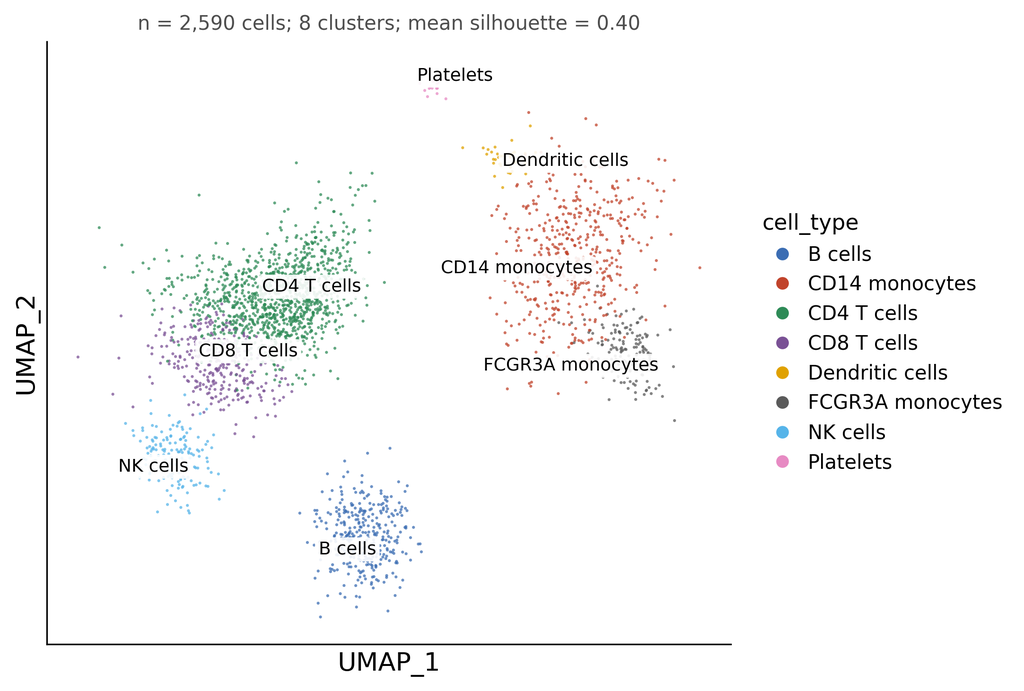

Publication figure

## Statistical results

| cluster | n | percent | median_x | median_y | mean_silhouette |
| --- | --- | --- | --- | --- | --- |
| B cells | 340 | 13.127413127413128 | -1.01855 | -7.38405 | 0.7738263939320378 |
| CD14 monocytes | 480 | 18.53281853281853 | 6.6319 | 2.82625 | 0.146251573699195 |
| CD4 T cells | 1100 | 42.47104247104247 | -4.0303 | 1.246 | 0.2852495934459613 |
| CD8 T cells | 300 | 11.583011583011583 | -6.3368 | -1.09775 | 0.42411817455741235 |
| Dendritic cells | 35 | 1.3513513513513513 | 4.2485 | 6.4481 | 0.7697215656941846 |
| FCGR3A monocytes | 160 | 6.177606177606178 | 8.5915 | -0.71375 | 0.6859572341045135 |
| NK cells | 160 | 6.177606177606178 | -7.87575 | -4.435499999999999 | 0.6469117997913899 |
| Platelets | 15 | 0.5791505791505791 | 1.5174 | 8.9143 | 0.8746337357295673 |

## Methods

The embedding coordinates UMAP_1 and UMAP_2 of 2,590 cells were computed upstream and are drawn as given; pubready does not compute the embedding. Points are coloured by cell_type (8 clusters), and each cluster is labelled at its median position. The mean silhouette width of each cluster was computed from the Euclidean distances between cells on the two embedding coordinates (the rules of cluster::silhouette, restated with numpy). It describes how well the clusters separate in the embedding, not in the original feature space, because an embedding such as UMAP or t-SNE distorts distances. The overall mean silhouette width was 0.397. Drawn in Python 3.10.12 with matplotlib 3.10.9 and adjustText 1.4.0.

## Plot configuration

The complete plot configuration is in `plot_config.yaml`.

## Provenance

| field | value |
| --- | --- |
| repository | pubready |
| repository_version | 4.0.0 |
| git_commit | 567ce8900bdb5db88369d131c8d787b042b3af57 |
| git_dirty | FALSE |
| llm_provider | none |
| llm_model | none |
| agent_harness | manual |
| agent_harness_version | not_recorded |
| container_image | localhost/pubready:4.0.0 |
| container_digest | sha256:0f57027a3fbca5ec9d41d74ca91226fbdf45d94b1a85f271637d12733db5d483 |
| input | {“file”: “input_umap_clusters.csv”, “md5”: “76d61b415aeb6c7f7cd1b8d152260faf”, “sha256”: “93e1dfb9a3457374ec2a570e17defd873f383468d2dd3ff0a70fb8f58f51b68f”} |
| command | figkit plot –recipe embedding |
| analysis_options | {“engine”: “python”, “recipe”: “embedding”, “data”: {“file”: “umap_clusters.csv”, “x”: “UMAP_1”, “y”: “UMAP_2”, “fill”: null, “facet”: null, “time”: null, “event”: null, “annotation”: null, “covariate… |
| random_seeds | not_applicable |
| session_record | session_info.txt |
| created_utc | 2026-07-18T00:00:00Z |
| review_state | not_applicable |
| reviewer | none |
| quarto_version | 1.11.4 |

The report source reads only files in this bundle.